# TASK 4 网络结构数据的可视化

狗熊会

仅仅通过邻接表和邻接矩阵很难直观地想象出网络的具体样貌及特征，因此需要将网络数据可视化成图。

任务介绍：本任务主要介绍网络结构数据的可视化及可使用的软件中，并学习如何使用R语言进行网络结构数据可视化。

这个案例的学习目标包括：

1. 了解网络可视化可使用的软件；
2. 学习图的布局以及R中如何设置；
3. 学习R中如何设置图中的节点和边的特征。

### 准备工作

```r
#清除工作环境
cat("\014");rm(list=ls())
```

```r
#加载相应的包,若没有,请先用 install.packages("igraph") 命令安装
library(igraph)
```

### 任务一: 介绍常用的网络可视化软件

在对网络进行可视化的工作中，我们可以借助几种常见的工具：

**Gephi**是一款开源免费跨平台的复杂网络分析软件，主要用于各种网络和复杂系统,是信息数据可视化的利器。Gephi是一种交互式系统，使用者无需编写代码，只需根据教程学习操作方法。使用者可以在“gephi.org”官网上下载此软件。

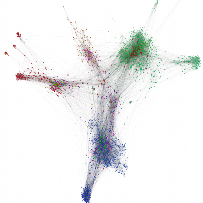

**Python**是一种跨平台的计算机程序设计语言，也是一种面向对象的脚本语言。Python提供了网络可视化的工具包**networkx**和**Igraph**。Igraph可以用于创建，操作和研究复杂网络系统;networkx用于构建和操作复杂的图结构，提供分析图的算法。

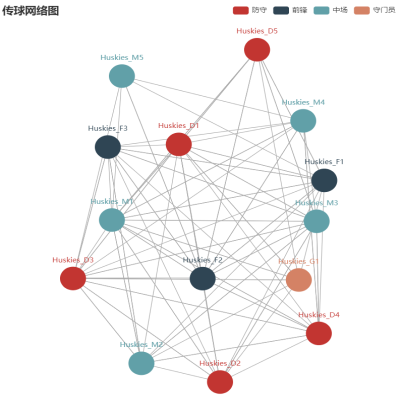

**R**是用于统计分析、绘图的语言和操作环境，具有优秀的统计计算和统计制图性能，并且是开源的。R同样提供了网络可视化的包，包括**igraph**，**network3d**。借助igraph可以对网络进行直观的展示，并且对布局方式等进行设置。

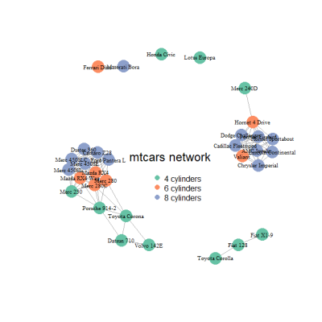

以上展示了一些使用不同软件绘制的图形结果，更多的图形结果及代码实现可以参考“R-graph-gallery”和“python graph gallery”网站等：

### 任务二: 介绍选择正确的图的布局的重要性以及常见的图布局方式

网络结构数据的连接关系可以由邻接表、邻接矩阵反映，但是使用者难以直观想象出该网络的具体样貌及特征。在可视化的过程中，同样的数据采用不同的布局画出的图给人的直观效果并不相同,因此在绘制图形的时候，要考虑到边和节点的位置给网络的直观效果带来的影响。绘制网络采用何种布局，主要取决于网络的种类、特征、以及研究的目的。

“karate_weight”数据集隶属于一个记载了某空手道俱乐部成员的对战胜负情况的数据集，“karate_weight”包括成员的对战记录和每次对战的重要程度。在任务三中，我们将使用“karate_weight”数据集，用三种常见的布局方式分别绘制网络结构图，并体会其中的差异，这三种布局是：

**随机布局：**节点和边完全随机放置。

**环形布局：**将节点全部放置在一个环上。

**力导向布局：**一种基于算法的布局方式，点的位置由彼此之间的路径长度决定，路径长度大的空间位置远，路径长度小的空间位置近。Fruchterman-Reingold是最常用的力导向布局算法。

### 任务三: 介绍R中如何设置布局方式

在R语言中，通过更改`plot()`函数的“layout”参数可以绘制不同布局的网络。在不同的布局下，网络呈现出的效果也有明显的差异。随机布局下的边有很多交叉，显得较为杂乱。环形布局则比较容易看出度比较大的节点的分布。力导向布局下，由于算法尽量减少了交叉，整体上较为整洁，并且容易看出哪些节点之间的路径长度较大。

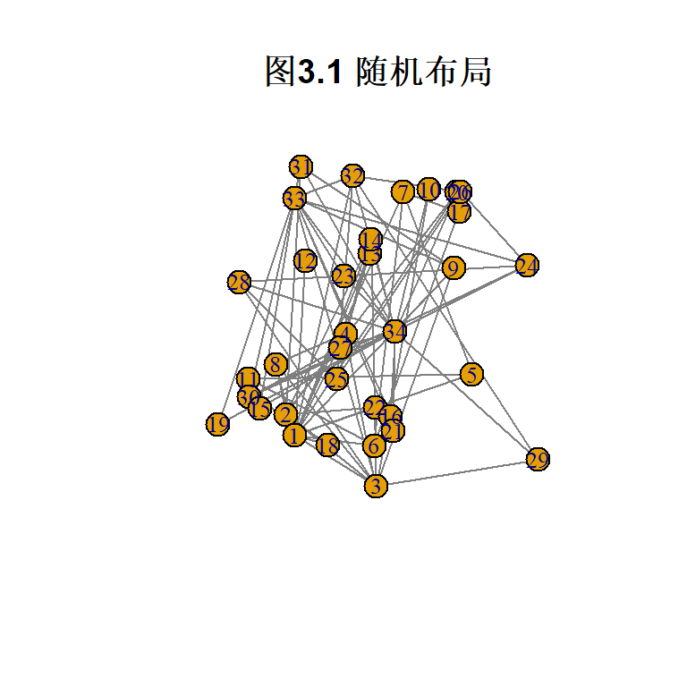

```r
kw = read.csv("karate_weight/karate_weight.csv",header = TRUE)        # 导入karate_weight数据
g = graph_from_data_frame(kw,directed = FALSE)                        # 构建无向有权网络

set.seed(100)
plot(g,
     vertex.label.cex=0.8,                   # 节点的标签字号
     vertex.label.dist=.05,                  # 节点的标签的位置
     layout=layout.random,                   # 随机布局
     edge.color="gray50",                    # 边的颜色
     main = "图3.1 随机布局")                # 设置标题
```

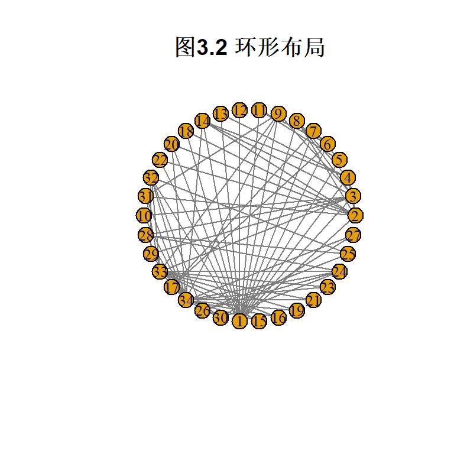

```r
plot(g,
     vertex.label.cex=0.8,                   # 节点的标签字号
     vertex.label.dist=.05,                  # 节点的标签的位置
     layout=layout.circle,                   # 环形布局
     edge.color="gray50",                    # 边的颜色
     main = "图3.2 环形布局")                # 设置标题
```

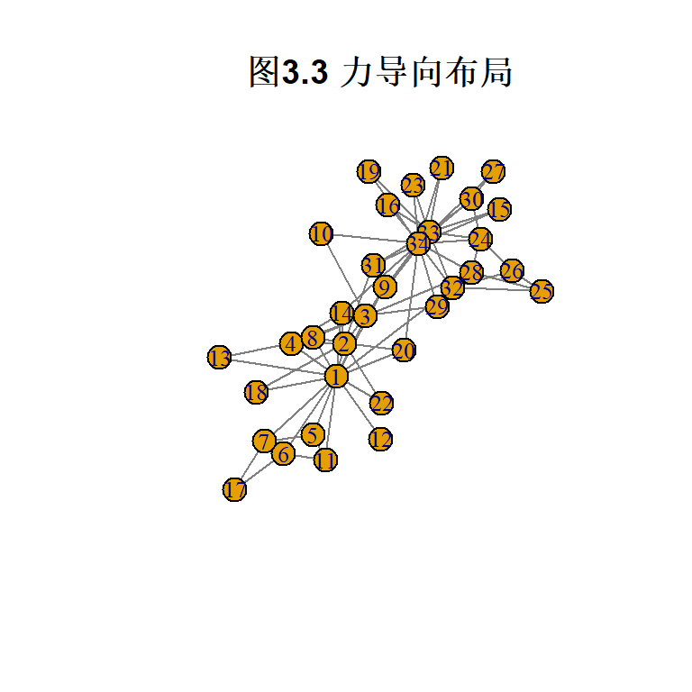

```r
plot(g,
     vertex.label.cex=0.8,                   # 节点的标签字号
     vertex.label.dist=.05,                  # 节点的标签的位置
     layout=layout.fruchterman.reingold,     # 力导向布局
     edge.color="gray50",                    # 边的颜色
     main = "图3.3 力导向布局")              # 设置标题
```

### 任务四: 介绍如何使用R在图中体现节点特性、标签、边权等特征

R语言中常使用`V(G)`或`vertex.XXX`来获取或设置节点属性；使用`E(G)`或`edge.XXX`来获取或设置连边属性，其中G是所构建或者所分析的网络。下面结合karate_weight具体来看这些函数的用法。

1. vertex.xxx和edge.xxx参数设置

常用节点和连边的设置参数如下，可根据实际数据选取合适的值使可视化图形更美观。

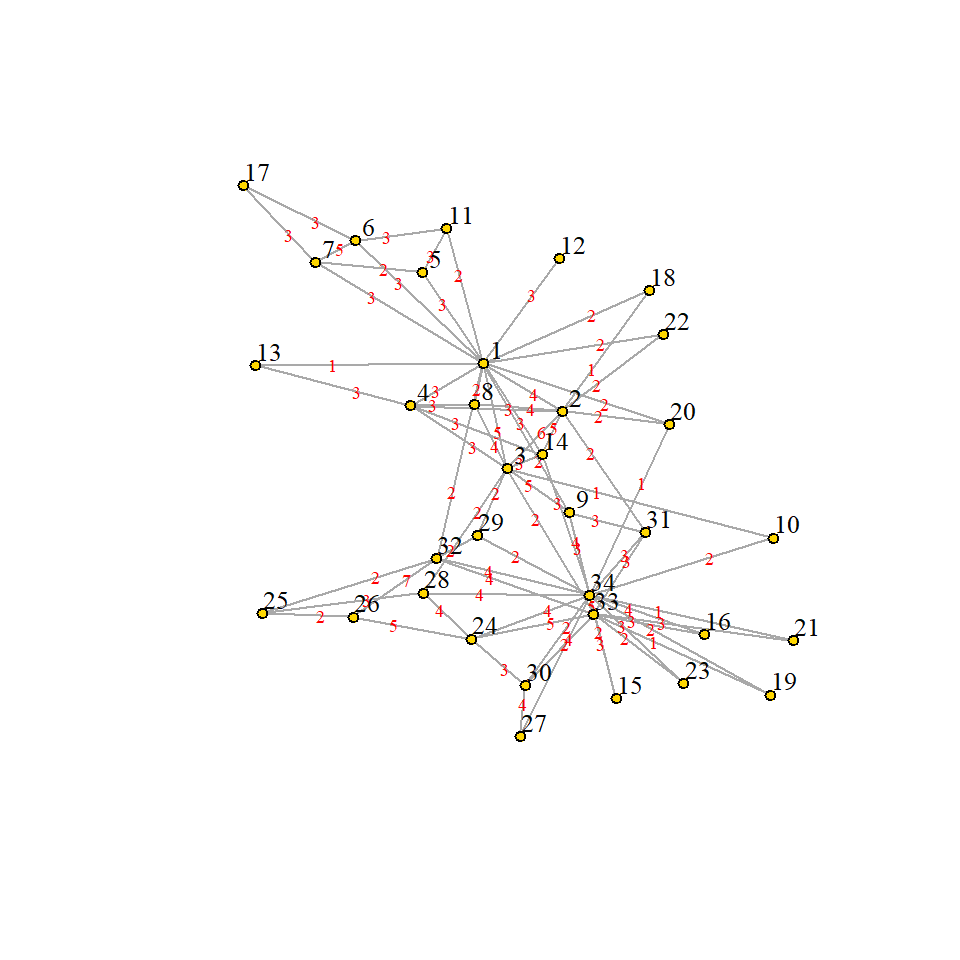

```r
#用vertex.xxx和edge.xxx参数设置节点和连边属性
set.seed(100)                               # 生成随机数种子，使每次绘制的网络图不变
plot(g,
     layout = layout.fruchterman.reingold,  # 设置为力导向布局
     vertex.size = 4,                       # 设置节点大小
     vertex.shape = 'circle',               # 节点不带边框none,,圆形边框circle,方块形rectangle
     vertex.color = 'gold',                 # 设置节点颜色
     vertex.label.cex = 0.8,                # 设置节点标签大小
     vertex.label.dist  = 1,                # 设置节点和标签的距离，便于错开重叠
     vertex.label.color = 'grey2',          # 设置节点标签颜色
     edge.label = E(g)$weight,              # 设置边权，此处直接使用数据集中的权重作为边权
     edge.label.cex = 0.6,                  # 设置边权标签大小
     edge.label.color = 'red')              # 设置边权标签颜色
```

2. vertex.xxx和edge.xxx参数设置，使节点和连边分别反映节点和边的特性

利用vertex.xxx和edge.xxx，也可以根据节点特性(如度、属性等)的不同绘制不同大小、颜色的节点，或根据连边特性(如边权、属性等)的不同绘制不同颜色、不同粗细的边以反映连边性质的差异。

为了展示上述操作，我们人为地给karate_weight数据添加节点属性性别和连边属性是否同性，然后绘制该网络的可视化图如下。如图所示，节点分为两种颜色，其中红色代表女性，蓝色代表男性，且节点的大小与节点度成正比；连边也类似，红色代表非同性友谊，蓝色代表同性友谊，且边宽与边权成正比。

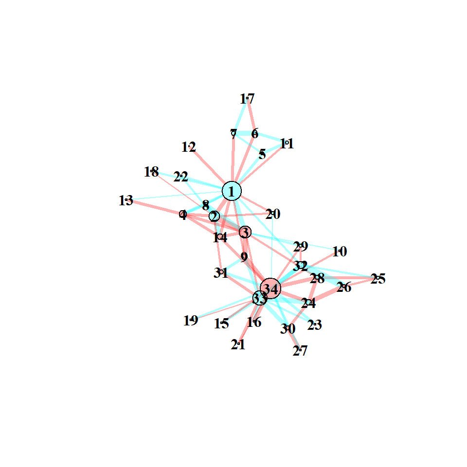

```r
n_node = length(V(g))                                      # 节点数
n_edge = length(E(g))                                      # 连边数
V(g)$gender = sample(c(0,1), n_node, rep = TRUE)           # 随机生成节点的性别属性,1代表男性,0代表女性
E(g)$is_same_gender = sample(c(0,1), n_edge, rep = TRUE)   # 随机生成连边的是否同性属性,1代表是同性,0代表非同性

set.seed(50)                                               # 生成随机数种子，使每次绘制的网络图不变
plot(g,
     # 边的颜色反映连边是否同性属性
     edge.color = rainbow(2,alpha = 0.3)[as.numeric(E(g)$is_same_gender)+1],
     edge.width = E(g)$weight,                            # 边的粗细程度反映权重
     vertex.label.color = 'black',                        # 设置节点标签颜色为黑色
     vertex.label.cex = 1,                                # 设置节点标签大小
     vertex.label.font = 2,                               # 设置节点标签字体为黑体
     vertex.size = degree(g),                             # 节点大小反映节点的度的大小
     # 节点颜色反映节点性别属性
     vertex.color = rainbow(2, alpha = 0.3)[as.numeric(V(g)$gender)+1])
```

3. 用`V(G)`和`E(G)`设置节点和连边的属性

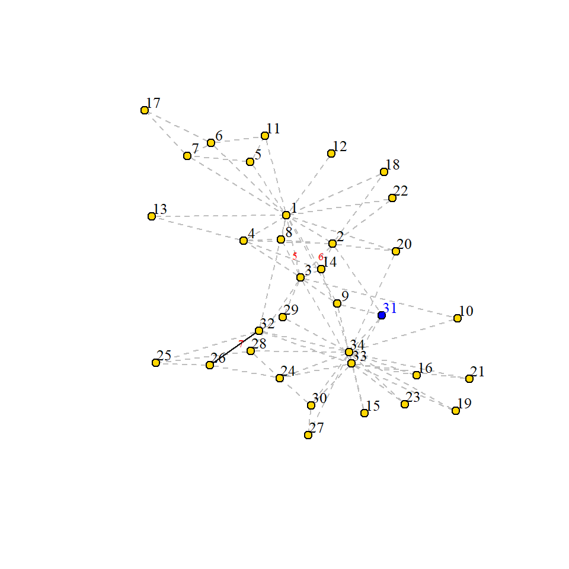

```r
#用V(g)和E(g)设置节点和连边的属性
set.seed(100)                               # 生成随机数种子，使每次绘制的网络图不变
#设置节点属性
V(g)$size = 5                               # 设置节点大小
V(g)$color = 'gold'                         # 设置节点颜色
V(g)$shape = 'circle'                       # 设置节点形状
V(g)$label.cex = 0.8                        # 设置节点标签大小
V(g)$label.dist = 1                         # 设置节点与标签的距离
V(g)$label.color = 'grey2'                  # 设置节点标签的颜色
V(g)[max(degree(g))]$color = "blue"         # 设置度最大的节点的颜色为蓝色
V(g)[max(degree(g))]$label.color = "blue"   # 设置度最大的节点的标签颜色为蓝色

#设置连边属性
E(g)$lty = 2                               # 设置边的类型，2表示虚线
E(g)$label.cex = 0.6                       # 设置边权标签大小
E(g)$color = "grey"                        # 设置连边颜色
E(g)[E(g)$weight == max(E(g)$weight)]$lty = 1                    # 设置权重最大的边的线性为实线
E(g)[E(g)$weight == max(E(g)$weight)]$color = "grey3"            # 设置权重最大的边的颜色为深灰色
# 添加权重最大的3条边的标签
E(g)[order(E(g)$weight,decreasing = T)[1:3]]$label = E(g)[order(E(g)$weight,decreasing = T)[1:3]]$weight
E(g)$label.color = 'red'                                         # 设置边权标签颜色

# 绘制网络图，图布局选取力导向布局
plot(g,layout=layout.fruchterman.reingold)
```

### 课后作业

1. 找到dolphins.txt文件，构建海豚网络，并进行可视化展示。（数据集介绍：每个节点代表生活在新西兰Doubtful Sound附近的一只海豚，连边代表两只海豚之间有频繁的联系。）
2. 选做：找一找公开资料或者网站中的比较美观的网络结构数据可视化。将可视化的图截取下来，并且用文字简要介绍 这个网络的节点和连边分别是什么。